# STAT 425 Homework 02

Yu Wu

2/19/2020

## Problem 1

### part a.

```r
library('faraway')
data(sat)

fit <- lm(total ~ expend + ratio + salary, data = sat)
summary(fit)
```

```
##
## Call:
## lm(formula = total ~ expend + ratio + salary, data = sat)
##
## Residuals:
##      Min       1Q   Median       3Q      Max
## -140.911  -46.740   -7.535   47.966  123.329
##
## Coefficients:
##             Estimate Std. Error t value Pr(>|t|)
## (Intercept) 1069.234    110.925   9.639 1.29e-12 ***
## expend        16.469     22.050   0.747   0.4589
## ratio          6.330      6.542   0.968   0.3383
## salary        -8.823      4.697  -1.878   0.0667 .
## ---
## Signif. codes:  0 '***' 0.001 '**' 0.01 '*' 0.05 '.' 0.1 ' ' 1
##
## Residual standard error: 68.65 on 46 degrees of freedom
## Multiple R-squared:  0.2096, Adjusted R-squared:  0.1581
## F-statistic: 4.066 on 3 and 46 DF,  p-value: 0.01209
```

The p-value for $\beta_{salary} = 0$ is 0.0667, greater than 0.05. Thus we do not reject the null.  
The p-value for $\beta_{salary} = \beta_{ratio}=\beta_{expend}=0$ is 0.01209, smaller than 0.05. Thus we reject the null. At least one of the predictors has effect on the response.

### part b.

```r
fit2 <- lm(total ~ expend + ratio + salary + takers, data = sat)
summary(fit2)
```

```
##
## Call:
## lm(formula = total ~ expend + ratio + salary + takers, data = sat)
##
## Residuals:
##     Min      1Q  Median      3Q     Max
## -90.531 -20.855  -1.746  15.979  66.571
##
## Coefficients:
##              Estimate Std. Error t value Pr(>|t|)
## (Intercept) 1045.9715    52.8698  19.784  < 2e-16 ***
## expend         4.4626    10.5465   0.423    0.674
## ratio         -3.6242     3.2154  -1.127    0.266
## salary         1.6379     2.3872   0.686    0.496
## takers        -2.9045     0.2313 -12.559 2.61e-16 ***
## ---
## Signif. codes:  0 '***' 0.001 '**' 0.01 '*' 0.05 '.' 0.1 ' ' 1
##
## Residual standard error: 32.7 on 45 degrees of freedom
## Multiple R-squared:  0.8246, Adjusted R-squared:  0.809
## F-statistic: 52.88 on 4 and 45 DF,  p-value: < 2.2e-16
```

```r
anova(fit, fit2)
```

```
## Analysis of Variance Table
##
## Model 1: total ~ expend + ratio + salary
## Model 2: total ~ expend + ratio + salary + takers
##   Res.Df    RSS Df Sum of Sq      F    Pr(>F)
## 1     46 216812
## 2     45  48124  1    168688 157.74 2.607e-16 ***
## ---
## Signif. codes:  0 '***' 0.001 '**' 0.01 '*' 0.05 '.' 0.1 ' ' 1
```

The p-value for $\beta_{takers} = 0$ is 2.61e-16 , smaller than 0.05. Thus we reject the null.

$$T =\frac{\hat{\beta_k-0}}{se(\hat{\beta_k})}=\frac{-2.9045}{0.2313 }=-12.557$$
$$F = 157.74$$

$$F = T^2$$

From the calculations above we can see that the F-test is equivalent to the t-test.

## Problem 2

```r
data("prostate")

fit <- lm(lpsa~.,data=prostate)
summary(fit)
```

```
##
## Call:
## lm(formula = lpsa ~ ., data = prostate)
##
## Residuals:
##     Min      1Q  Median      3Q     Max
## -1.7331 -0.3713 -0.0170  0.4141  1.6381
##
## Coefficients:
##              Estimate Std. Error t value Pr(>|t|)
## (Intercept)  0.669337   1.296387   0.516  0.60693
## lcavol       0.587022   0.087920   6.677 2.11e-09 ***
## lweight      0.454467   0.170012   2.673  0.00896 **
## age         -0.019637   0.011173  -1.758  0.08229 .
## lbph         0.107054   0.058449   1.832  0.07040 .
## svi          0.766157   0.244309   3.136  0.00233 **
## lcp         -0.105474   0.091013  -1.159  0.24964
## gleason      0.045142   0.157465   0.287  0.77503
## pgg45        0.004525   0.004421   1.024  0.30886
## ---
## Signif. codes:  0 '***' 0.001 '**' 0.01 '*' 0.05 '.' 0.1 ' ' 1
##
## Residual standard error: 0.7084 on 88 degrees of freedom
## Multiple R-squared:  0.6548, Adjusted R-squared:  0.6234
## F-statistic: 20.86 on 8 and 88 DF,  p-value: < 2.2e-16
```

### part a.

```r
sum_fit <- summary(fit)
beta_age <- sum_fit$coefficients['age', 1]
beta_age_err <- sum_fit$coefficients['age', 2]

df <- nrow(prostate) - ncol(prostate)

t095 <- qt(0.975, df)
t090 <- qt(0.95, df)

ci95 <- beta_age + c(-1, 1)*t095*beta_age_err
ci90 <- beta_age + c(-1, 1)*t090*beta_age_err


ci90
```

```
## [1] -0.038210200 -0.001064151
```

```r
ci95
```

```
## [1] -0.041840618  0.002566267
```

### part b.

```r
fit2 <- lm(lpsa ~ lcavol + lweight + svi,data=prostate)
anova(fit2, fit)
```

```
## Analysis of Variance Table
##
## Model 1: lpsa ~ lcavol + lweight + svi
## Model 2: lpsa ~ lcavol + lweight + age + lbph + svi + lcp + gleason +
##     pgg45
##   Res.Df    RSS Df Sum of Sq      F Pr(>F)
## 1     93 47.785
## 2     88 44.163  5    3.6218 1.4434 0.2167
```

The p-value is larger than 0.05 and thus do not reject the null. Therefore the reduced model is better.

### part c.

```r
library(ellipse)
```

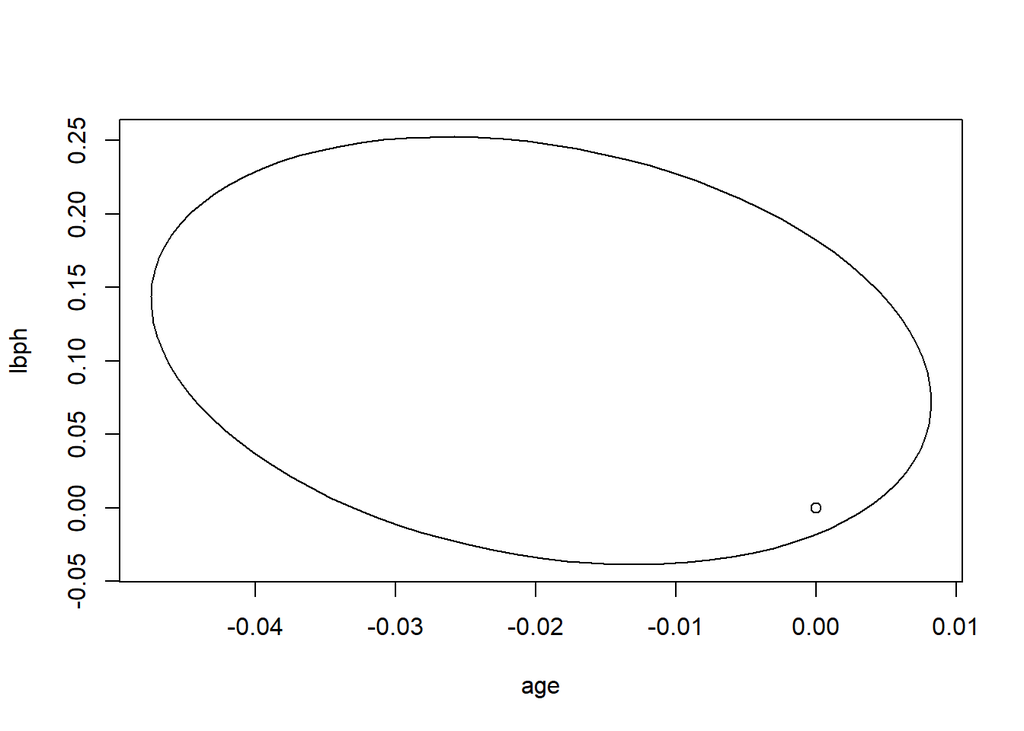

```r
plot(ellipse(fit, c(4,5)), type = 'l')
points(0,0)
```

The origin stays in the ellipse, therefore we cannot reject the null hypothesis.

### part d.

```r
n.iter <- 5000
tstats <- numeric(n.iter)
for (i in 1:n.iter) {
  temp_fit <- lm(lpsa ~ lcavol + lweight + sample(age) + lbph + svi + lcp + gleason + pgg45, data = prostate)
  tstats[i] <- summary(temp_fit)$coefficients[4,3]
}
mean(abs(tstats) > abs(summary(fit)$coefficients[4,3]))
```

```
## [1] 0.08
```

## Problem 3

### part a.

```r
data('punting')
fit <- lm(Distance ~ RStr + LStr + RFlex + LFlex, data = punting)
summary(fit)
```

```
##
## Call:
## lm(formula = Distance ~ RStr + LStr + RFlex + LFlex, data = punting)
##
## Residuals:
##     Min      1Q  Median      3Q     Max
## -23.941  -8.958  -4.441  13.523  17.016
##
## Coefficients:
##             Estimate Std. Error t value Pr(>|t|)
## (Intercept) -79.6236    65.5935  -1.214    0.259
## RStr          0.5116     0.4856   1.054    0.323
## LStr         -0.1862     0.5130  -0.363    0.726
## RFlex         2.3745     1.4374   1.652    0.137
## LFlex        -0.5277     0.8255  -0.639    0.541
##
## Residual standard error: 16.33 on 8 degrees of freedom
## Multiple R-squared:  0.7365, Adjusted R-squared:  0.6047
## F-statistic:  5.59 on 4 and 8 DF,  p-value: 0.01902
```

All of the predictors have p-value greater than 0.05, thus none of them is significant at 5% level.

### part b.

```r
fit2 <- lm(Distance ~ 1, data = punting)
anova(fit2, fit)
```

```
## Analysis of Variance Table
##
## Model 1: Distance ~ 1
## Model 2: Distance ~ RStr + LStr + RFlex + LFlex
##   Res.Df    RSS Df Sum of Sq      F  Pr(>F)
## 1     12 8093.3
## 2      8 2132.6  4    5960.7 5.5899 0.01902 *
## ---
## Signif. codes:  0 '***' 0.001 '**' 0.01 '*' 0.05 '.' 0.1 ' ' 1
```

The p-value for the F-test is 0.01902, smaller than 0.05. Therefore at least one of them is significant.

### part c.

```r
fit3 <- lm(Distance ~ I(RStr + LStr) + RFlex+LFlex, data=punting)
anova(fit3, fit)
```

```
## Analysis of Variance Table
##
## Model 1: Distance ~ I(RStr + LStr) + RFlex + LFlex
## Model 2: Distance ~ RStr + LStr + RFlex + LFlex
##   Res.Df    RSS Df Sum of Sq      F Pr(>F)
## 1      9 2287.4
## 2      8 2132.6  1    154.72 0.5804  0.468
```

### part d.

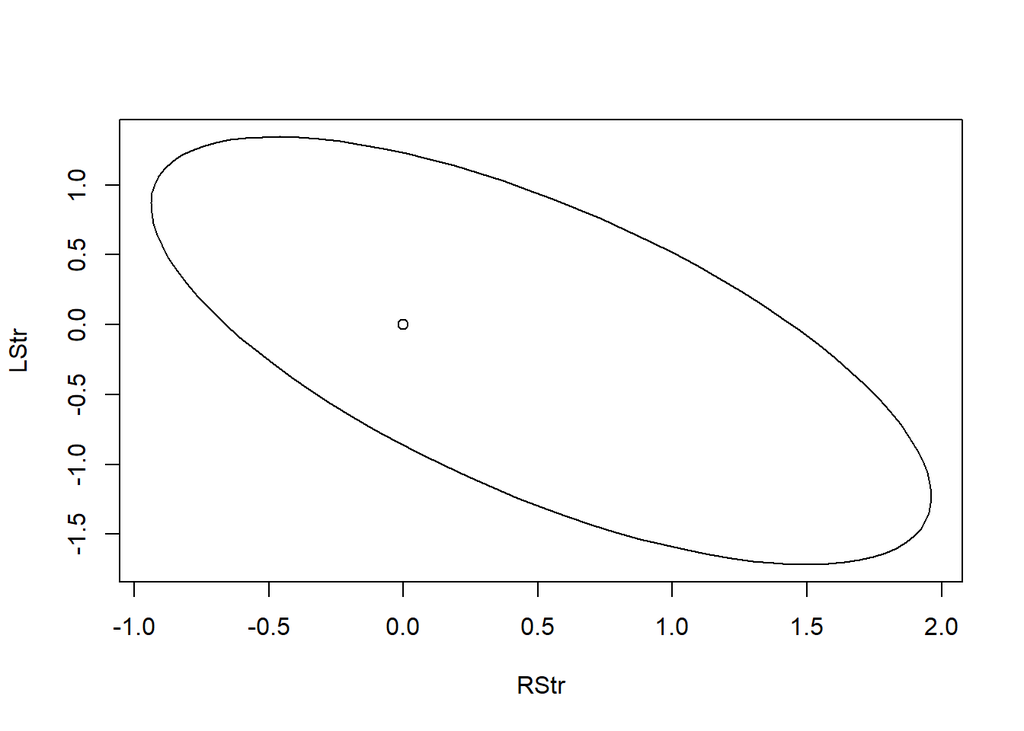

```r
plot(ellipse(fit, c(2,3), level = 0.95), type = 'l')
points(0,0)
```

Since the origin lies within the ellipse, we cannot reject the null hypothesis.

### part e.

```r
fit4 <- lm(Distance ~ I(RStr + LStr) + RFlex + LFlex, data=punting)
fit5 <- lm(Distance ~ I(RStr + LStr), data=punting)
anova(fit4, fit5)
```

```
## Analysis of Variance Table
##
## Model 1: Distance ~ I(RStr + LStr) + RFlex + LFlex
## Model 2: Distance ~ I(RStr + LStr)
##   Res.Df    RSS Df Sum of Sq      F Pr(>F)
## 1      9 2287.4
## 2     11 3061.3 -2      -774 1.5227 0.2694
```

Since the p-value of the F-Test is greater than 0.05, we cannot reject the null and total leg strength defined by adding the right and left leg strengths is sufficient to predict the response.

## Problem 5

### part a.

```r
data(prostate)
fit=lm(lpsa~., data = prostate)
x=data.frame(lcavol = 1.44692, lweight =  3.62301, age = 65, lbph=0.3001, svi = 0, lcp = -0.79851, gleason = 7, pgg45 = 15)
predict(fit, x, interval="prediction")
```

```
##        fit       lwr      upr
## 1 2.389053 0.9646584 3.813447
```

### part b.

```r
data(prostate)
fit=lm(lpsa~., data = prostate)
x=data.frame(lcavol = 1.44692, lweight =  3.62301, age = 20, lbph=0.3001, svi = 0, lcp = -0.79851, gleason = 7, pgg45 = 15)
predict(fit, x, interval="prediction")
```

```
##        fit      lwr      upr
## 1 3.272726 1.538744 5.006707
```

The reason of new CI being wider is that age is smaller and further away from mean.

### part c.

```r
summary(fit)
```

```
##
## Call:
## lm(formula = lpsa ~ ., data = prostate)
##
## Residuals:
##     Min      1Q  Median      3Q     Max
## -1.7331 -0.3713 -0.0170  0.4141  1.6381
##
## Coefficients:
##              Estimate Std. Error t value Pr(>|t|)
## (Intercept)  0.669337   1.296387   0.516  0.60693
## lcavol       0.587022   0.087920   6.677 2.11e-09 ***
## lweight      0.454467   0.170012   2.673  0.00896 **
## age         -0.019637   0.011173  -1.758  0.08229 .
## lbph         0.107054   0.058449   1.832  0.07040 .
## svi          0.766157   0.244309   3.136  0.00233 **
## lcp         -0.105474   0.091013  -1.159  0.24964
## gleason      0.045142   0.157465   0.287  0.77503
## pgg45        0.004525   0.004421   1.024  0.30886
## ---
## Signif. codes:  0 '***' 0.001 '**' 0.01 '*' 0.05 '.' 0.1 ' ' 1
##
## Residual standard error: 0.7084 on 88 degrees of freedom
## Multiple R-squared:  0.6548, Adjusted R-squared:  0.6234
## F-statistic: 20.86 on 8 and 88 DF,  p-value: < 2.2e-16
```

The insignificant variables are age, lbph, lcp, gleason, pgg45.

```r
fit=lm(lpsa ~ lcavol+lweight+svi, data = prostate)
predict(fit, x, interval="prediction")
```

```
##        fit       lwr      upr
## 1 2.372534 0.9383436 3.806724
```

The CI becomes narrower. I would prefer the original model since the reduced model might generate wrong results when dealing with much younger or older people.